# **Diplomado IA: Relacional, GANs, RL, Meta-Learning, Razonamiento y Memoria**. Práctico 27: Redes Neuronales de Grafos

**Profesor:**

- Carlos Aspillaga

# **Instrucciones Generales**

El siguiente práctico se debe realizar **individualmente**. El formato de entrega es el **archivo .ipynb con todas las celdas ejecutadas**. Todas las preguntas deben ser respondidas en las celdas dispuestas para ello. No se aceptará el *output* de una celda de código como respuesta.

**Nombre alumno:** ROBERTO ARANEDA ESPINOZA

El siguiente práctico cuenta con varias secciones y en varias de ellas se incluye actividades a realizar.

**IMPORTANTE: habrá un bonus de 1 décima para todos aquellos alumnos/as que muestren buen orden en sus respuestas (esto aplica a legibilidad de código, buena redacción, formalidad, organización del jupyter notebook, seguimiento de instrucciones, etc). El criterio lo pondrá cada ayudante corrector. La nota máxima obtenible en el laboratorio es 7.0**

# **Índice**

> Diplomado IA: Relacional, GANs, RL, Meta-Learning, Razonamiento y Memoria. Práctico 27: Redes Neuronales de Grafos

> Instrucciones Generales

> Índice

> Instalación de dependencias

> Explorando Grafos con Pytorch Geometric

> Usando Redes Neuronales de Grafos

> > Ejemplo básico de clasificación de nodos

> > Ejemplo más avanzado de clasificación de nodos

> > Ejemplo de clasificación de Grafos

> > (Material Opcional) Probando la técnica de Morris et al.

> (Material Opcional) Trucos útiles

> > ¿Qué hago si mi grafo es tan grande que no cabe en GPU?

> > ¿Cómo creo Grafos y Dataloaders con mis propios datos?

> > ¿Cómo lo hago si quiero explorar arquitecturas de GNN más "a la medida" o usar otros modelos?

> Actividades

> > Actividad 1:

> > Actividad 2:

> > Actividad 3:

> > Actividad 4:

> > Actividad 5

> > Actividad 6

**Créditos**: Parcialmente basado en ejemplos de https://pytorch-geometric.readthedocs.io/

# **Instalación de dependencias**

Primero instalamos librerías considerando la versión activa de torch y cuda.

Es necesario instalar versiones especificas para compatibilidad de la libreria pytorch Geometric que se instalará

```python
import sys, subprocess, torch

print("Torch:", torch.__version__, "| CUDA:", torch.version.cuda)

# Generamos la URL del Wheel considerando la versión de Torch+CUDA:
torch_ver = torch.__version__.split('+')[0]  # e.g., '2.10.0'
cuda_tag  = 'cpu' if torch.version.cuda is None else 'cu' + ''.join(torch.version.cuda.split('.'))  # e.g., 'cu128'
index_url = f"https://data.pyg.org/whl/torch-{torch_ver}+{cuda_tag}.html"
print("PyG wheel index:", index_url)

extensions = ["torch-scatter", "torch-sparse", "torch-cluster", "torch-spline-conv"]
print(f"Installing standard extensions: {extensions}")
subprocess.check_call([sys.executable, "-m", "pip", "install", "-U"] + extensions + ["-f", index_url])

# Instalamos torch-geometric
print("Installing torch-geometric and louvain")
subprocess.check_call([sys.executable, "-m", "pip", "install", "-U", "torch-geometric", "python-louvain"])
```

```
Torch: 2.11.0+cu128 | CUDA: 12.8
PyG wheel index: https://data.pyg.org/whl/torch-2.11.0+cu128.html
Installing standard extensions: ['torch-scatter', 'torch-sparse', 'torch-cluster', 'torch-spline-conv']
Installing torch-geometric and louvain
```

```
0
```

# **Explorando Grafos con Pytorch Geometric**

En esta primera actividad, exploraremos un dataset tradicional de grafos llamado "Karate Club Network", propuesto por Wayne W. Zachary en su paper “An Information Flow Model for Conflict and Fission in Small Groups”, en 1977

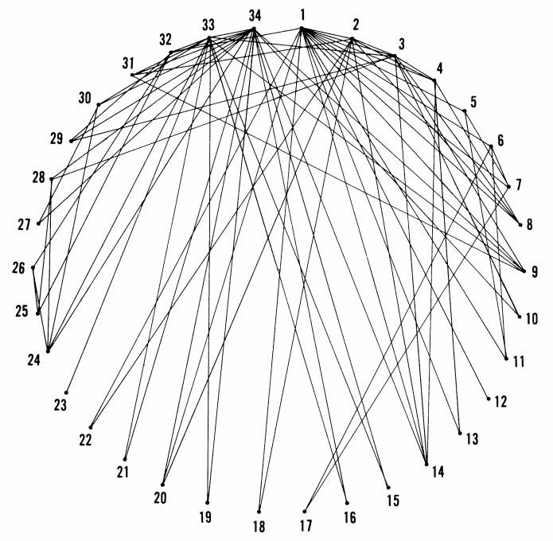

```python
!if [ ! -f karate_club.png ]; then wget -q https://www.dropbox.com/s/inmyr76hbhrgb5h/karate_club.png; fi
import IPython
import pylab
%matplotlib inline
pil_img = IPython.display.Image(filename='karate_club.png', width=450, height=450)
IPython.display.display(pil_img)
```

> "*A line is drawn between two points when the two individuals being represented consistently interacted in contexts outside those of karate classes, workouts, and club meetings.*"

> > **Fuente**: *paper original "An Information Flow Model for Conflict and Fission in Small Groups"*

El dataset contiene grafos almacendados en objetos de tipo `Data`. Estas clases de Pytorch Geometric tienen atributos que permiten revisar sus estadísticas

```python
from torch_geometric.datasets import KarateClub

dataset = KarateClub()
print(f'Number of graphs: {len(dataset)}')
print(f'Number of features: {dataset.num_features}')
print(f'Number of classes: {dataset.num_classes}')

data = dataset[0]  # Obtener el primer (y único) grafo como objeto de clase Data
print(f'Number of nodes: {data.num_nodes}')
print(f'Number of edges: {data.num_edges}')
print(f'Average node degree: {data.num_edges / data.num_nodes:.2f}')
print(f'Contains isolated nodes: {data.has_isolated_nodes()}')
print(f'Contains self-loops: {data.has_self_loops()}')
print(f'Is undirected: {data.is_undirected()}')
```

```
Number of graphs: 1
Number of features: 34
Number of classes: 4
Number of nodes: 34
Number of edges: 156
Average node degree: 4.59
Contains isolated nodes: False
Contains self-loops: False
Is undirected: True
```

Mediante el atributo `edge_index` podemos explorar las aristas del grafo. Aqui observamos las aristas desde el indice 10 al 29

```python
edge_index = data.edge_index
print(edge_index.t()[10:30,:])
```

```
tensor([[ 0, 12],
        [ 0, 13],
        [ 0, 17],
        [ 0, 19],
        [ 0, 21],
        [ 0, 31],
        [ 1,  0],
        [ 1,  2],
        [ 1,  3],
        [ 1,  7],
        [ 1, 13],
        [ 1, 17],
        [ 1, 19],
        [ 1, 21],
        [ 1, 30],
        [ 2,  0],
        [ 2,  1],
        [ 2,  3],
        [ 2,  7],
        [ 2,  8]])
```

Mediante el atributo `x` podemos explorar los features de los nodos. En este caso son simplemente vectores de tipo "one-hot", que no aportan informacion muy util del nodo

```python
features = data.x
print(features.t()[:10,:10])
```

```
tensor([[1., 0., 0., 0., 0., 0., 0., 0., 0., 0.],
        [0., 1., 0., 0., 0., 0., 0., 0., 0., 0.],
        [0., 0., 1., 0., 0., 0., 0., 0., 0., 0.],
        [0., 0., 0., 1., 0., 0., 0., 0., 0., 0.],
        [0., 0., 0., 0., 1., 0., 0., 0., 0., 0.],
        [0., 0., 0., 0., 0., 1., 0., 0., 0., 0.],
        [0., 0., 0., 0., 0., 0., 1., 0., 0., 0.],
        [0., 0., 0., 0., 0., 0., 0., 1., 0., 0.],
        [0., 0., 0., 0., 0., 0., 0., 0., 1., 0.],
        [0., 0., 0., 0., 0., 0., 0., 0., 0., 1.]])
```

Mediante el atributo `y` podemos explorar los labels (clases)

```python
classes = data.y
print(classes.t()[:10])
```

```
tensor([1, 1, 1, 1, 3, 3, 3, 1, 0, 1])
```

A continuación visualizaremos el Grafo

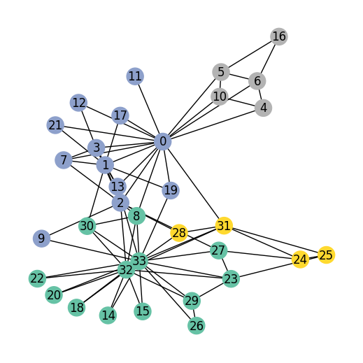

```python
%matplotlib inline
import time
import numpy as np
import imageio
import torch
import matplotlib.pyplot as plt
import networkx as nx
from sklearn.manifold import TSNE
from IPython.display import Javascript, Image, display
from torch_geometric.utils import to_networkx


def visualize_graph(G, color, layout_seed=42, return_frame=False, with_labels=True):

    WIDTH_PX, HEIGHT_PX, DPI = 500, 500, 100
    figsize = (WIDTH_PX / DPI, HEIGHT_PX / DPI)

    fig = plt.figure(figsize=figsize, dpi=DPI)
    ax = fig.add_subplot(111)
    pos = nx.spring_layout(G, seed=layout_seed)

    color_np = color.detach().cpu().numpy() if torch.is_tensor(color) else np.asarray(color)
    nx.draw_networkx(
        G, pos=pos, with_labels=with_labels,
        node_color=color_np, cmap="Set2", ax=ax
    )
    ax.set_axis_off()
    fig.tight_layout(pad=0)

    if return_frame:
        fig.canvas.draw()
        w, h = fig.canvas.get_width_height()
        buf = np.frombuffer(fig.canvas.buffer_rgba(), dtype=np.uint8).reshape(h, w, 4)
        frame = buf[..., :3].copy()
        plt.close(fig)
        return frame
    else:
        plt.show()
        return None

G = to_networkx(data, to_undirected=True)
visualize_graph(G, color=data.y)
```

De la imagen anterior, vemos cierto ordenamiendo de los nodos. Esto proviene de la libreria que estamos usando, que busca la forma de mostrar el grafo tal que se visualice bien, pero en realidad no existe un ordenamiento predefinido para ubicar los nodos en la visualizacion.

# **Usando Redes Neuronales de Grafos**

## Ejemplo básico de clasificación de nodos

Para este ejemplo usaremos una capa de tipo **GCN**, propuesta por [Kipf et al. (2017)](https://arxiv.org/abs/1609.02907), que se define como

$$ \mathbf{h}_i^{(t + 1)} = \mathbf{W}^{(t + 1)} \sum_{j \in \mathcal{N}(i) \, \cup \, \{ i \}} \frac{1}{c_{i,j}} \cdot \mathbf{h}_j^{(t)} $$

donde $\mathbf{W}^{(t + 1)}$ es una matriz entrenable de tamaño `[num_output_features, num_input_features]` y $c_{i,j}$ es un coeficiente fijo de normalización por cada arista.

Pytorch Geometric implementa esta capa mediante la clase [`GCNConv`](https://pytorch-geometric.readthedocs.io/en/latest/modules/nn.html#torch_geometric.nn.conv.GCNConv) y el modo de uso es (casi) idéntico a como usamos las convoluciones de pytorch para imágenes.

```python
import torch
from torch.nn import Linear
from torch_geometric.nn import GCNConv

class GCN(torch.nn.Module):
    def __init__(self):
        super(GCN, self).__init__()
        torch.manual_seed(1)
        # creamos nuestra GCN con 3 capas convolucionales
        self.conv1 = GCNConv(dataset.num_features, 4)
        self.conv2 = GCNConv(4, 4)
        self.conv3 = GCNConv(4, 2)
        # finalmente nuestra capa de clasificación a num_clases
        self.classifier = Linear(2, dataset.num_classes)

    def forward(self, x, edge_index):
        h = self.conv1(x, edge_index)
        h = h.tanh()
        h = self.conv2(h, edge_index)
        h = h.tanh()
        h = self.conv3(h, edge_index)
        h = h.tanh()
        out = self.classifier(h)
        return out, h
```

Ahora podemos visualizar nuestra GCN antes de entrenar. Es interesante ver que a pesar de tener pesos **completamente aleatorios** sin ningún tipo de entrenamiento, la forma en que se definen las convoluciones de grafos introduce un bias inductivo poderoso, generando embeddings que se asemejan a la estructura de comunidad del grafo al asignar embeddings similares a nodos cercanos en el grafo.

```python
import numpy as np
import matplotlib.pyplot as plt
from sklearn.manifold import TSNE
import torch

WIDTH_PX, HEIGHT_PX, DPI = 450, 450, 100
_FIGSIZE = (WIDTH_PX / DPI, HEIGHT_PX / DPI)

def _fig_to_rgb_array(fig):
    # para dibujar a imagen RGB: ndarray (H, W, 3)
    fig.canvas.draw()
    w, h = fig.canvas.get_width_height()
    buf = np.frombuffer(fig.canvas.buffer_rgba(), dtype=np.uint8).reshape(h, w, 4)
    rgb = buf[..., :3].copy()
    plt.close(fig)
    return rgb

def visualize_embedding(
    h,
    color,
    epoch=None,
    loss=None,
    tsne: bool = False,
    return_frame: bool = False,
    point_size: int = 140,
    cmap: str = "Set2",
    dpi: int = 120,   # kept for backward compat; ignored because size is hard-coded
):
    # normalizar inputs
    h_np = h.detach().cpu().numpy() if torch.is_tensor(h) else np.asarray(h)
    color_np = color.detach().cpu().numpy() if torch.is_tensor(color) else np.asarray(color)

    # elegir representacion 2D segun corresponda (normal o TSNE)
    use_tsne = tsne or (h_np.ndim != 2) or (h_np.shape[1] != 2)
    xy = TSNE(n_components=2, init="pca").fit_transform(h_np) if use_tsne else h_np[:, :2]

    # Dibujar
    fig = plt.figure(figsize=_FIGSIZE, dpi=DPI)
    ax = fig.add_subplot(111)
    ax.scatter(
        xy[:, 0], xy[:, 1],
        s=point_size if not use_tsne else max(70, point_size // 2),
        c=color_np, cmap=cmap
    )
    ax.set_xticks([]); ax.set_yticks([])
    if epoch is not None and loss is not None:
        loss_val = float(loss.item() if hasattr(loss, "item") else loss)
        ax.set_xlabel(f"Epoch: {epoch}  |  Loss: {loss_val:.4f}", fontsize=14)
    fig.tight_layout(pad=0)

    if return_frame:
        return _fig_to_rgb_array(fig)
    else:
        plt.show()
        return None
```

```
Embedding shape: [34, 2]
```

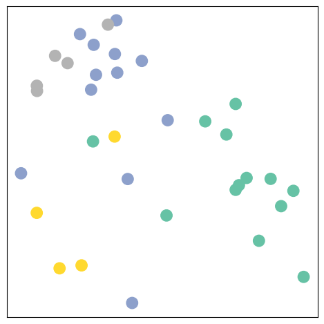

```python
model = GCN()
model.eval()

with torch.no_grad():
    _, h = model(data.x, data.edge_index)
print(f'Embedding shape: {list(h.shape)}')

visualize_embedding(h, color=data.y)
```

Ahora entrenemos nuestra **GCN** para ver si es capaz de generar una mejor separación de las clases

```python
from IPython.display import Javascript, Image, display
import imageio.v2 as imageio
import torch

# Aquí definimos nuestro modelo, función de pérdida y optimizador
model = GCN()
criterion = torch.nn.CrossEntropyLoss()
optimizer = torch.optim.Adam(model.parameters(), lr=0.01)

def train_step(data):
    optimizer.zero_grad()  # resetear gradientes
    out, h = model(data.x, data.edge_index)  # forward pass.
    loss = criterion(out[data.train_mask], data.y[data.train_mask])  # calcular pérdida basados en los nodos de training
    loss.backward()  # backward pass.
    optimizer.step()  # actualización de pesos (guiados por el gradiente).
    return loss, h

# Parametros para capturar a GIF
every_n = 10          # capturar un frame cada N epocas
frame_duration = 0.30 # duracion en segundos de cada frame en el GIF
frames = []

# Frame inicial (epoca 0, antes de entrenar)
with torch.no_grad():
    _, h0 = model(data.x, data.edge_index)
frame0 = visualize_embedding(h0, color=data.y, epoch=0, loss=0.0, return_frame=True)
frames.append(frame0)

# Loop de entrenamiento
for epoch in range(1, 801):
    loss, h = train_step(data)
    if epoch % every_n == 0:
        frame = visualize_embedding(h, color=data.y, epoch=epoch, loss=loss, return_frame=True)
        frames.append(frame)


gif_path = "/content/gcn_training.gif"
imageio.mimsave(gif_path, frames, duration=frame_duration, loop=0)  # 0 = loop infinito
display(Image(gif_path))
```

[output not shown]

## Ejemplo más avanzado de clasificación de nodos

En este ejemplo usaremos un grafo más complejo, llamado "Cora" que contiene información de publicaciones (papers), cada uno con features indicando la presencia o ausencia de ciertas palabras clave, y una clase (categoría del paper). El grafo se construye mediante las citas de un paper referenciando a otro.

```python
from torch_geometric.datasets import Planetoid
from torch_geometric.transforms import NormalizeFeatures

dataset = Planetoid(root='data/Planetoid', name='Cora', transform=NormalizeFeatures())

print(f'Number of graphs: {len(dataset)}')
print(f'Number of features: {dataset.num_features}')
print(f'Number of classes: {dataset.num_classes}')

data = dataset[0] # Obtener el primer (y unico) grafo, como objeto de clase Data
print(f'Number of nodes: {data.num_nodes}')
print(f'Number of edges: {data.num_edges}')
print(f'Average node degree: {data.num_edges / data.num_nodes:.2f}')
print(f'Contains isolated nodes: {data.has_isolated_nodes()}')
print(f'Contains self-loops: {data.has_self_loops()}')
print(f'Is undirected: {data.is_undirected()}')
```

```
Downloading https://github.com/kimiyoung/planetoid/raw/master/data/ind.cora.x
Downloading https://github.com/kimiyoung/planetoid/raw/master/data/ind.cora.tx
Downloading https://github.com/kimiyoung/planetoid/raw/master/data/ind.cora.allx
Downloading https://github.com/kimiyoung/planetoid/raw/master/data/ind.cora.y
Downloading https://github.com/kimiyoung/planetoid/raw/master/data/ind.cora.ty
Downloading https://github.com/kimiyoung/planetoid/raw/master/data/ind.cora.ally
Downloading https://github.com/kimiyoung/planetoid/raw/master/data/ind.cora.graph
Downloading https://github.com/kimiyoung/planetoid/raw/master/data/ind.cora.test.index
Processing...
```

```
Number of graphs: 1
Number of features: 1433
Number of classes: 7
Number of nodes: 2708
Number of edges: 10556
Average node degree: 3.90
Contains isolated nodes: False
Contains self-loops: False
Is undirected: True
```

```
Done!
```

```python
def train(some_model, some_data):
      some_model.train()
      optimizer.zero_grad()  # resetear gradientes
      out = some_model(some_data.x)  # forward pass.
      loss = criterion(out[some_data.train_mask], some_data.y[some_data.train_mask])  # calcular pérdida basados en los nodos de training
      loss.backward()  # backward pass.
      optimizer.step()  # actualización de pesos (guiados por el gradiente).
      return loss

def test(some_model, some_data):
      some_model.eval()
      out = some_model(some_data.x)
      pred = out.argmax(dim=1)  # Usar la clase con probabilidad mas alta
      test_correct = pred[some_data.test_mask] == some_data.y[some_data.test_mask]  # Comparar con Ground Truth
      test_acc = int(test_correct.sum()) / int(some_data.test_mask.sum())  # correctos dividido totales
      return test_acc
```

Para tener un punto de comparacion, a continuación crearemos un clasificador tipo MLP que sea capaz de distinguir entre las distintas categorías de papers a partir de los features (ignorando el gráfico)

```python
import torch
from torch.nn import Linear
import torch.nn.functional as F

class MLP(torch.nn.Module):
    def __init__(self, hidden_channels):
        super(MLP, self).__init__()
        torch.manual_seed(12345)
        self.lin1 = Linear(dataset.num_features, hidden_channels)
        self.lin2 = Linear(hidden_channels, dataset.num_classes)

    def forward(self, x):
        x = self.lin1(x)
        x = x.relu()
        x = F.dropout(x, p=0.5, training=self.training)
        x = self.lin2(x)
        return x

# Aquí creamos nuestro modelo, función de pérdida y optimizador
model = MLP(hidden_channels=16)
criterion = torch.nn.CrossEntropyLoss()  # Define loss criterion.
optimizer = torch.optim.Adam(model.parameters(), lr=0.01, weight_decay=5e-4)  # Define optimizer.

for epoch in range(1, 201):
    loss = train(model, data)
    print(f'Epoch: {epoch:03d}, Loss: {loss:.4f}')
```

```
Epoch: 001, Loss: 1.9609
Epoch: 002, Loss: 1.9558
Epoch: 003, Loss: 1.9485
Epoch: 004, Loss: 1.9413
Epoch: 005, Loss: 1.9297
Epoch: 006, Loss: 1.9266
Epoch: 007, Loss: 1.9124
Epoch: 008, Loss: 1.9024
Epoch: 009, Loss: 1.8985
Epoch: 010, Loss: 1.8849
Epoch: 011, Loss: 1.8753
Epoch: 012, Loss: 1.8684
Epoch: 013, Loss: 1.8483
Epoch: 014, Loss: 1.8465
Epoch: 015, Loss: 1.8115
Epoch: 016, Loss: 1.8143
Epoch: 017, Loss: 1.7900
Epoch: 018, Loss: 1.7985
Epoch: 019, Loss: 1.7639
Epoch: 020, Loss: 1.7383
Epoch: 021, Loss: 1.7229
Epoch: 022, Loss: 1.7452
Epoch: 023, Loss: 1.7000
Epoch: 024, Loss: 1.6855
Epoch: 025, Loss: 1.6691
Epoch: 026, Loss: 1.6479
Epoch: 027, Loss: 1.6284
Epoch: 028, Loss: 1.5960
Epoch: 029, Loss: 1.5562
Epoch: 030, Loss: 1.5396
Epoch: 031, Loss: 1.5488
Epoch: 032, Loss: 1.5224
Epoch: 033, Loss: 1.4665
Epoch: 034, Loss: 1.4885
Epoch: 035, Loss: 1.4399
Epoch: 036, Loss: 1.4035
Epoch: 037, Loss: 1.4265
Epoch: 038, Loss: 1.3742
Epoch: 039, Loss: 1.3742
Epoch: 040, Loss: 1.3391
```

[output cut: 145 more lines]

```
Epoch: 186, Loss: 0.4846
Epoch: 187, Loss: 0.4696
Epoch: 188, Loss: 0.4537
Epoch: 189, Loss: 0.4547
Epoch: 190, Loss: 0.4602
Epoch: 191, Loss: 0.4548
Epoch: 192, Loss: 0.4516
Epoch: 193, Loss: 0.4540
Epoch: 194, Loss: 0.4303
Epoch: 195, Loss: 0.4404
Epoch: 196, Loss: 0.4452
Epoch: 197, Loss: 0.4560
Epoch: 198, Loss: 0.4428
Epoch: 199, Loss: 0.4487
Epoch: 200, Loss: 0.4827
```

```python
test_acc = test(model, data)
print(f'Test Accuracy: {test_acc:.4f}')
```

```
Test Accuracy: 0.5740
```

Ahora que sabemos el rendimiento de un modelo tipo MLP, probemos el rendimiento con un modelo para grafos

```python
from torch_geometric.nn import GCNConv

class GCN(torch.nn.Module):
    def __init__(self, hidden_channels):
        super(GCN, self).__init__()
        torch.manual_seed(12345)
        self.conv1 = GCNConv(dataset.num_features, hidden_channels)
        self.conv2 = GCNConv(hidden_channels, dataset.num_classes)

    def forward(self, x, edge_index):
        x = self.conv1(x, edge_index)
        x = x.relu()
        x = F.dropout(x, p=0.5, training=self.training)
        x = self.conv2(x, edge_index)
        return x
```

Antes que todo revisemos cómo separa las clases antes de empezar a entrenar

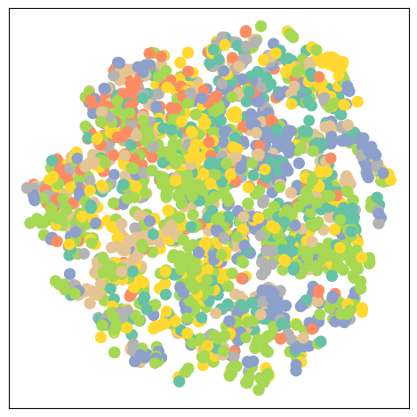

```python
model = GCN(hidden_channels=16)
model.eval()

out = model(data.x, data.edge_index)
visualize_embedding(out, color=data.y, tsne=True)
```

Ahora repitamos el entrenamiento, pero esta vez usando la GCN

```python
def train():
      model.train()
      optimizer.zero_grad()  # Clear gradients.
      out = model(data.x, data.edge_index)  # Perform a single forward pass.
      loss = criterion(out[data.train_mask], data.y[data.train_mask])  # Compute the loss solely based on the training nodes.
      loss.backward()  # Derive gradients.
      optimizer.step()  # Update parameters based on gradients.
      return loss

def test():
      model.eval()
      out = model(data.x, data.edge_index)
      pred = out.argmax(dim=1)  # Use the class with highest probability.
      test_correct = pred[data.test_mask] == data.y[data.test_mask]  # Check against ground-truth labels.
      test_acc = int(test_correct.sum()) / int(data.test_mask.sum())  # Derive ratio of correct predictions.
      return test_acc


model = GCN(hidden_channels=16)
optimizer = torch.optim.Adam(model.parameters(), lr=0.01, weight_decay=5e-4)
criterion = torch.nn.CrossEntropyLoss()


for epoch in range(1, 201):
    loss = train()
    print(f'Epoch: {epoch:03d}, Loss: {loss:.4f}')
```

```
Epoch: 001, Loss: 1.9460
Epoch: 002, Loss: 1.9409
Epoch: 003, Loss: 1.9351
Epoch: 004, Loss: 1.9291
Epoch: 005, Loss: 1.9214
Epoch: 006, Loss: 1.9151
Epoch: 007, Loss: 1.9055
Epoch: 008, Loss: 1.8978
Epoch: 009, Loss: 1.8876
Epoch: 010, Loss: 1.8769
Epoch: 011, Loss: 1.8684
Epoch: 012, Loss: 1.8598
Epoch: 013, Loss: 1.8505
Epoch: 014, Loss: 1.8459
Epoch: 015, Loss: 1.8276
Epoch: 016, Loss: 1.8214
Epoch: 017, Loss: 1.8033
Epoch: 018, Loss: 1.7914
Epoch: 019, Loss: 1.7905
Epoch: 020, Loss: 1.7760
Epoch: 021, Loss: 1.7688
Epoch: 022, Loss: 1.7338
Epoch: 023, Loss: 1.7234
Epoch: 024, Loss: 1.6937
Epoch: 025, Loss: 1.6972
Epoch: 026, Loss: 1.6778
Epoch: 027, Loss: 1.6697
Epoch: 028, Loss: 1.6445
Epoch: 029, Loss: 1.6269
Epoch: 030, Loss: 1.6204
Epoch: 031, Loss: 1.5859
Epoch: 032, Loss: 1.5751
Epoch: 033, Loss: 1.5629
Epoch: 034, Loss: 1.5522
Epoch: 035, Loss: 1.5046
Epoch: 036, Loss: 1.4897
Epoch: 037, Loss: 1.4730
Epoch: 038, Loss: 1.4604
Epoch: 039, Loss: 1.4494
Epoch: 040, Loss: 1.4216
```

[output cut: 145 more lines]

```
Epoch: 186, Loss: 0.3675
Epoch: 187, Loss: 0.3258
Epoch: 188, Loss: 0.3438
Epoch: 189, Loss: 0.3462
Epoch: 190, Loss: 0.3363
Epoch: 191, Loss: 0.3380
Epoch: 192, Loss: 0.3560
Epoch: 193, Loss: 0.3477
Epoch: 194, Loss: 0.3448
Epoch: 195, Loss: 0.2951
Epoch: 196, Loss: 0.3125
Epoch: 197, Loss: 0.3379
Epoch: 198, Loss: 0.3410
Epoch: 199, Loss: 0.3196
Epoch: 200, Loss: 0.3278
```

```python
test_acc = test()
print(f'Test Accuracy: {test_acc:.4f}')
```

```
Test Accuracy: 0.8130
```

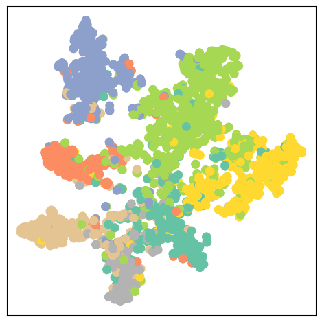

```python
model.eval()

out = model(data.x, data.edge_index)
visualize_embedding(out, color=data.y, tsne=True)
```

Con esto vemos que la GCN hace un muy buen trabajo separando las clases, gracias a que considera la informacion de conectividad de los nodos.

## Ejemplo de clasificación de Grafos

En algunos casos, en lugar de querer clasificar nodos, nos interesa clasificar grafos completos. A continuación haremos clasificación de moléculas (a partir del grafo que representa los enlaces entre los átomos que la componen).

Existen muchos datasets (algunos enormes) con este tipo de información. A continuación usaremos el **MUTAG dataset**, que es más pequeño. Este dataset clasifica moléculas según si inhiben o no la replicación del virus VIH.

Si inspeccionamos el dataset, veremos que tiene 188 grafos. Podemos inspeccionar cada uno por separado (en el ejemplo, revisaremos solo uno, lo cual se refleja en la linea data = dataset[15], es decir, tomamos el grafo de indice 15)

```python
import torch
from torch_geometric.datasets import TUDataset

dataset = TUDataset(root='data/TUDataset', name='MUTAG')

print(f'Number of graphs: {len(dataset)}')
print(f'Number of features: {dataset.num_features}')
print(f'Number of classes: {dataset.num_classes}')


print('-'*50+"\nInformation of the Graph #15")
data = dataset[15] # obtengamos uno de los 188 grafos
print(f'Number of nodes: {data.num_nodes}')
print(f'Number of edges: {data.num_edges}')
print(f'Average node degree: {data.num_edges / data.num_nodes:.2f}')
print(f'Contains isolated nodes: {data.has_isolated_nodes()}')
print(f'Contains self-loops: {data.has_self_loops()}')
print(f'Is undirected: {data.is_undirected()}')
```

```
Number of graphs: 188
Number of features: 7
Number of classes: 2
--------------------------------------------------
Information of the Graph #15
Number of nodes: 22
Number of edges: 50
Average node degree: 2.27
Contains isolated nodes: False
Contains self-loops: False
Is undirected: True
```

```
Downloading https://www.chrsmrrs.com/graphkerneldatasets/MUTAG.zip
Processing...
Done!
```

PyTorch Geometric entrega funcionalidades para desordenar de manera aleatoria el orden de los grafos. Usaremos esa herramienta para dividir nuestro dataset en 150 para training y los 38 restantes para test:

```python
from torch_geometric.loader import DataLoader

torch.manual_seed(12345)
dataset = dataset.shuffle()

train_dataset = dataset[:150]
test_dataset = dataset[150:]

print(f'Number of training graphs: {len(train_dataset)}')
print(f'Number of test graphs: {len(test_dataset)}')

train_loader = DataLoader(train_dataset, batch_size=64, shuffle=True)
test_loader = DataLoader(test_dataset, batch_size=64, shuffle=False)
```

```
Number of training graphs: 150
Number of test graphs: 38
```

Ahora crearemos nuestra GNN compuesto de tres convoluciones de grafos y un clasificador lineal final.

```python
from torch.nn import Linear
import torch.nn.functional as F
from torch_geometric.nn import GCNConv
from torch_geometric.nn import global_mean_pool


class GCN(torch.nn.Module):
    def __init__(self, hidden_channels):
        super(GCN, self).__init__()
        torch.manual_seed(12345)
        self.conv1 = GCNConv(dataset.num_node_features, hidden_channels)
        self.conv2 = GCNConv(hidden_channels, hidden_channels)
        self.conv3 = GCNConv(hidden_channels, hidden_channels)
        self.lin = Linear(hidden_channels, dataset.num_classes)

    def forward(self, x, edge_index, batch):
        # 1. Calcular los embeddings de los nodos
        x = self.conv1(x, edge_index)
        x = x.relu()
        x = self.conv2(x, edge_index)
        x = x.relu()
        x = self.conv3(x, edge_index)

        # 2. Leer los embeddings de todos los nodos (Readout)
        x = global_mean_pool(x, batch)  # [batch_size, hidden_channels]

        # 3. Aplicar dropout y un clasificador lineal
        x = F.dropout(x, p=0.5, training=self.training)
        x = self.lin(x)

        return x
```

Definimos los metodos de train y test, identicos a los que usariamos en una red convolucional como las que hemos visto en clases anteriores.

```python
def train(loader, model):
    model.train()
    for data in loader:
         out = model(data.x, data.edge_index, data.batch)
         loss = criterion(out, data.y)
         loss.backward()
         optimizer.step()
         optimizer.zero_grad()

def test(loader, model):
     model.eval()
     correct = 0
     for data in loader:
         out = model(data.x, data.edge_index, data.batch)
         pred = out.argmax(dim=1)  # Usar la clase con mayor probabilidad
         correct += int((pred == data.y).sum())  # Comparar con las etiquetas reales
     return correct / len(loader.dataset)  # Retornar el porcentaje de clasificaciones correctas

model = GCN(hidden_channels=64)
optimizer = torch.optim.Adam(model.parameters(), lr=0.01)
criterion = torch.nn.CrossEntropyLoss()

for epoch in range(1, 201):
    train(train_loader, model)
    train_acc = test(train_loader, model)
    print(f'Epoch: {epoch:03d}, Train Acc: {train_acc:.4f}')
```

```
Epoch: 001, Train Acc: 0.6467
Epoch: 002, Train Acc: 0.6467
Epoch: 003, Train Acc: 0.6467
Epoch: 004, Train Acc: 0.6467
Epoch: 005, Train Acc: 0.6467
Epoch: 006, Train Acc: 0.6733
Epoch: 007, Train Acc: 0.7267
Epoch: 008, Train Acc: 0.6867
Epoch: 009, Train Acc: 0.7133
Epoch: 010, Train Acc: 0.7133
Epoch: 011, Train Acc: 0.7133
Epoch: 012, Train Acc: 0.7267
Epoch: 013, Train Acc: 0.7200
Epoch: 014, Train Acc: 0.7133
Epoch: 015, Train Acc: 0.7267
Epoch: 016, Train Acc: 0.7333
Epoch: 017, Train Acc: 0.7200
Epoch: 018, Train Acc: 0.7400
Epoch: 019, Train Acc: 0.7400
Epoch: 020, Train Acc: 0.7200
Epoch: 021, Train Acc: 0.7467
Epoch: 022, Train Acc: 0.7467
Epoch: 023, Train Acc: 0.7333
Epoch: 024, Train Acc: 0.7533
Epoch: 025, Train Acc: 0.7267
Epoch: 026, Train Acc: 0.7200
Epoch: 027, Train Acc: 0.7533
Epoch: 028, Train Acc: 0.7600
Epoch: 029, Train Acc: 0.7600
Epoch: 030, Train Acc: 0.7200
Epoch: 031, Train Acc: 0.7533
Epoch: 032, Train Acc: 0.7533
Epoch: 033, Train Acc: 0.7600
Epoch: 034, Train Acc: 0.7267
Epoch: 035, Train Acc: 0.7533
Epoch: 036, Train Acc: 0.7600
Epoch: 037, Train Acc: 0.7600
Epoch: 038, Train Acc: 0.7733
Epoch: 039, Train Acc: 0.7667
Epoch: 040, Train Acc: 0.7667
```

[output cut: 145 more lines]

```
Epoch: 186, Train Acc: 0.8467
Epoch: 187, Train Acc: 0.8333
Epoch: 188, Train Acc: 0.8333
Epoch: 189, Train Acc: 0.8533
Epoch: 190, Train Acc: 0.8333
Epoch: 191, Train Acc: 0.8667
Epoch: 192, Train Acc: 0.8533
Epoch: 193, Train Acc: 0.8600
Epoch: 194, Train Acc: 0.8733
Epoch: 195, Train Acc: 0.8600
Epoch: 196, Train Acc: 0.8533
Epoch: 197, Train Acc: 0.8600
Epoch: 198, Train Acc: 0.8733
Epoch: 199, Train Acc: 0.8467
Epoch: 200, Train Acc: 0.8600
```

```python
test_acc = test(test_loader, model)
print(f'Test Acc: {test_acc:.4f}')
```

```
Test Acc: 0.7105
```

Vemos que el modelo logra un buen rendimiento a pesar de usar una red muy sencilla y muy pocos datos

## (Material Opcional) Probando la técnica de Morris et al.

Algunos papers ([Xu et al. (2018)](https://arxiv.org/abs/1810.00826), [Morris et al. (2018)](https://arxiv.org/abs/1810.02244)), muestran que la normalización de vecinos perjudican la expresividad de las GNN para distinguir ciertos tipos de estructuras de grafos.

[Morris et al. (2018)](https://arxiv.org/abs/1810.02244) quita la normalización en la etapa de agregación de mensajes y agrega una skip-connection para permitir que la red preserve la información original de cada nodo:

$$ \mathbf{h}_i^{(t+1)} = \mathbf{W}^{(t + 1)}_A \mathbf{h}_i^{(t)} + \mathbf{W}^{(t + 1)}_B \sum_{j \in \mathcal{N}(i)} \mathbf{h}_j^{(t)} $$

Para usar esta capa basta con usar su implementación en la clase [`GraphConv`](https://pytorch-geometric.readthedocs.io/en/latest/modules/nn.html#torch_geometric.nn.conv.GraphConv) de PyTorch Geometric en lugar de la GCNConv que usamos *anteriormente*.

```python
from torch_geometric.nn import GraphConv


class GNN(torch.nn.Module):
    def __init__(self, hidden_channels):
        super(GNN, self).__init__()
        torch.manual_seed(12345)
        self.conv1 = GraphConv(dataset.num_node_features, hidden_channels)
        self.conv2 = GraphConv(hidden_channels, hidden_channels)
        self.conv3 = GraphConv(hidden_channels, hidden_channels)
        self.lin = Linear(hidden_channels, dataset.num_classes)

    def forward(self, x, edge_index, batch):
        x = self.conv1(x, edge_index)
        x = x.relu()
        x = self.conv2(x, edge_index)
        x = x.relu()
        x = self.conv3(x, edge_index)

        x = global_mean_pool(x, batch)

        x = F.dropout(x, p=0.5, training=self.training)
        x = self.lin(x)

        return x
```

```python
model = GNN(hidden_channels=64)
print(model)
optimizer = torch.optim.Adam(model.parameters(), lr=0.01)

for epoch in range(1, 201):
    train(train_loader, model)
    train_acc = test(train_loader, model)
    print(f'Epoch: {epoch:03d}, Train Acc: {train_acc:.4f}')
```

```
GNN(
  (conv1): GraphConv(7, 64)
  (conv2): GraphConv(64, 64)
  (conv3): GraphConv(64, 64)
  (lin): Linear(in_features=64, out_features=2, bias=True)
)
Epoch: 001, Train Acc: 0.6467
Epoch: 002, Train Acc: 0.6467
Epoch: 003, Train Acc: 0.6467
Epoch: 004, Train Acc: 0.6467
Epoch: 005, Train Acc: 0.6467
Epoch: 006, Train Acc: 0.7067
Epoch: 007, Train Acc: 0.7267
Epoch: 008, Train Acc: 0.7267
Epoch: 009, Train Acc: 0.7800
Epoch: 010, Train Acc: 0.7667
Epoch: 011, Train Acc: 0.7933
Epoch: 012, Train Acc: 0.7667
Epoch: 013, Train Acc: 0.7933
Epoch: 014, Train Acc: 0.7800
Epoch: 015, Train Acc: 0.7667
Epoch: 016, Train Acc: 0.7733
Epoch: 017, Train Acc: 0.7800
Epoch: 018, Train Acc: 0.7933
Epoch: 019, Train Acc: 0.7733
Epoch: 020, Train Acc: 0.8067
Epoch: 021, Train Acc: 0.7933
Epoch: 022, Train Acc: 0.7800
Epoch: 023, Train Acc: 0.7733
Epoch: 024, Train Acc: 0.8067
Epoch: 025, Train Acc: 0.7867
Epoch: 026, Train Acc: 0.7800
Epoch: 027, Train Acc: 0.8133
Epoch: 028, Train Acc: 0.8133
Epoch: 029, Train Acc: 0.8067
Epoch: 030, Train Acc: 0.8067
Epoch: 031, Train Acc: 0.8267
Epoch: 032, Train Acc: 0.8133
Epoch: 033, Train Acc: 0.7933
Epoch: 034, Train Acc: 0.8067
```

[output cut: 151 more lines]

```
Epoch: 186, Train Acc: 0.9467
Epoch: 187, Train Acc: 0.9467
Epoch: 188, Train Acc: 0.9467
Epoch: 189, Train Acc: 0.9400
Epoch: 190, Train Acc: 0.9467
Epoch: 191, Train Acc: 0.9467
Epoch: 192, Train Acc: 0.9467
Epoch: 193, Train Acc: 0.9467
Epoch: 194, Train Acc: 0.9400
Epoch: 195, Train Acc: 0.9400
Epoch: 196, Train Acc: 0.9400
Epoch: 197, Train Acc: 0.9467
Epoch: 198, Train Acc: 0.9467
Epoch: 199, Train Acc: 0.9467
Epoch: 200, Train Acc: 0.9467
```

```python
test_acc = test(test_loader, model)
print(f'Test Acc: {test_acc:.4f}')
```

```
Test Acc: 0.8158
```

Con esto vemos que el pequenio cambio que introduce Morris et al. produce una mejora importante en el resultado, lo cual se explica por el hecho de que en estos casos permite a la red diferenciar la cantidad de aristas que llegan a cada nodo (una GCN comun pierde esa informacion al preservar solo el valor promedio)

# **(Material Opcional) Trucos útiles**

## ¿Qué hago si mi grafo es tan grande que no cabe en GPU?

Podemos usar una técnica llamada **Cluster-GCN**, propuesta por [Chiang et al. (2019)](https://arxiv.org/abs/1905.07953), que consiste en pre-particionar el grafo en subgrafos, de tal manera de que puedan ser usados en un minibatch.

A pesar de su simpleza, esta técnica ha resultado ser muy poderosa para trabajar con grafos enormes.

```python
import torch
from torch_geometric.datasets import Planetoid
from torch_geometric.transforms import NormalizeFeatures

dataset = Planetoid(root='data/Planetoid', name='PubMed', transform=NormalizeFeatures())

print()
print(f'Dataset: {dataset}:')
print('==================')
print(f'Number of graphs: {len(dataset)}')
print(f'Number of features: {dataset.num_features}')
print(f'Number of classes: {dataset.num_classes}')

data = dataset[0]  # Get the first graph object.

print()
print(data)
print('===============================================================================================================')

# Gather some statistics about the graph.
print(f'Number of nodes: {data.num_nodes}')
print(f'Number of edges: {data.num_edges}')
print(f'Average node degree: {data.num_edges / data.num_nodes:.2f}')
print(f'Number of training nodes: {data.train_mask.sum()}')
print(f'Training node label rate: {int(data.train_mask.sum()) / data.num_nodes:.3f}')
print(f'Contains isolated nodes: {data.has_isolated_nodes()}')
print(f'Contains self-loops: {data.has_self_loops()}')
print(f'Is undirected: {data.is_undirected()}')
```

```
Downloading https://github.com/kimiyoung/planetoid/raw/master/data/ind.pubmed.x
Downloading https://github.com/kimiyoung/planetoid/raw/master/data/ind.pubmed.tx
Downloading https://github.com/kimiyoung/planetoid/raw/master/data/ind.pubmed.allx
Downloading https://github.com/kimiyoung/planetoid/raw/master/data/ind.pubmed.y
Downloading https://github.com/kimiyoung/planetoid/raw/master/data/ind.pubmed.ty
Downloading https://github.com/kimiyoung/planetoid/raw/master/data/ind.pubmed.ally
Downloading https://github.com/kimiyoung/planetoid/raw/master/data/ind.pubmed.graph
Downloading https://github.com/kimiyoung/planetoid/raw/master/data/ind.pubmed.test.index
Processing...
```

```
Dataset: PubMed():
==================
Number of graphs: 1
Number of features: 500
Number of classes: 3

Data(x=[19717, 500], edge_index=[2, 88648], y=[19717], train_mask=[19717], val_mask=[19717], test_mask=[19717])
===============================================================================================================
Number of nodes: 19717
Number of edges: 88648
Average node degree: 4.50
Number of training nodes: 60
Training node label rate: 0.003
Contains isolated nodes: False
Contains self-loops: False
Is undirected: True
```

```
Done!
```

```python
from torch_geometric.loader import ClusterData, ClusterLoader

cluster_data = ClusterData(data, num_parts=128)  # 1. Crear el objeto encargado de particionar en sub-grafos
train_loader = ClusterLoader(cluster_data, batch_size=32, shuffle=True)  # 2. El dataloader se encarga de mostrar sub-grafos diferentes en cada iteración
```

```
Computing METIS partitioning...
Done!
```

Y listo! Ahora podemos usar este nuevo dataloader como si fuera uno normal (como en los ejemplos anteriores), y dejamos toda la responsabilidad de particionar los grafos a las clases ClusterData y ClusterLoader

## ¿Cómo creo Grafos y Dataloaders con mis propios datos?

Se puede hacer creando un objeto de tipo `Data` para cada grafo del dataset. Ojo que aqui pusimos [...] para representar la matriz de datos propias del problema que usted busca resolver y Data(...) para representar el Dataset que usted haya creado. Por esa razon estas celdas aun no estan listas para ejecutarse.

```python
from torch_geometric.data import Data
from torch_geometric.loader import DataLoader

nodes_features = torch.tensor([...]) # Tensor (opcional) de tamaño [num_nodes, num_features]
edges = torch.tensor([...], dtype=torch.long) # LongTensor (opcional) de tamaño [2, num_edges] representando las aristas
y = torch.tensor([...]) # Tensor (opcional) de tamaño [num_nodes, num_clases] con la(s) clase(s) de los nodos. Tipicamente num_clases es 1, pero es posible usar más

data = Data(x=nodes_features, edge_index=edges, y=y)

# opcionalmente se puede definir propiedades a la medida
data.train_idx = torch.tensor([...], dtype=torch.long)
data.test_mask = torch.tensor([...], dtype=torch.bool)
```

```python
import torch
from torch_geometric.data import Data
from torch_geometric.loader import DataLoader

# 4 nodos, cada uno con 2 features
nodes_features = torch.tensor([
    [1.0, 0.0],
    [0.0, 1.0],
    [1.0, 1.0],
    [0.5, 0.5],
], dtype=torch.float)                       # [num_nodes=4, num_features=2]

# aristas en formato COO [2, num_edges]: fila 0 = origen, fila 1 = destino
# grafo no dirigido 0-1, 1-2, 2-3  → cada arista en ambas direcciones
edges = torch.tensor([
    [0, 1, 1, 2, 2, 3],
    [1, 0, 2, 1, 3, 2],
], dtype=torch.long)                        # [2, num_edges=6]

# una clase por nodo
y = torch.tensor([0, 1, 1, 0], dtype=torch.long)   # [num_nodes]

data = Data(x=nodes_features, edge_index=edges, y=y)

# propiedades a la medida (opcionales)
data.train_mask = torch.tensor([True,  True,  False, False])
data.test_mask  = torch.tensor([False, False, True,  True])

print(data)
print(f'Nodos: {data.num_nodes} | Aristas: {data.num_edges} | Grado prom: {data.num_edges / data.num_nodes:.2f}')
print(f'¿No dirigido?: {data.is_undirected()}')
```

```
Data(x=[4, 2], edge_index=[2, 6], y=[4], train_mask=[4], test_mask=[4])
Nodos: 4 | Aristas: 6 | Grado prom: 1.50
¿No dirigido?: True
```

```python
data_list = [Data(...), ..., Data(...)]
loader = DataLoader(data_list, batch_size=32)
```

## ¿Cómo lo hago si quiero explorar arquitecturas de GNN más "a la medida" o usar otros modelos?

Pytorch Geometric trae implementados diversos tipos de capas que pueden ser ensamblados libremente como si se tratara de piezas de lego.

Para ver el detalle de todos los componentes disponibles, ir a https://pytorch-geometric.readthedocs.io/en/latest/modules/nn.html

Particularmente trae implementadas todas las arquitecturas que revisamos en clases:

- graphSAGE (SAGEConv)
- gated GNN (GatedGraphConv)
- GCN (GCNConv)

Incluso tambien trae implementadas algunas capas más avanzadas y recientes (algunas de este año). Por ejemplo algunas basadas en atención o inspiradas en transformer

- TransformerConv
- AGNNConv

Además trae varios modelos completos implementados https://pytorch-geometric.readthedocs.io/en/latest/modules/nn.html#models

# **Actividades**

## Actividad 1:

**En la actividad donde usamos una GCN para el dataset de "Karate Club" vimos que al aplicar una GCN sobre los datos, se puede apreciar un ligero ordenamiento de los nodos, que tiene cierta correspondencia con los grupos existentes entre los individuos. ¿De dónde proviene esa información, considerando que los pesos están aun en sus valores aleatorios iniciales?**

```python
#@title Respuesta 1

Respuesta = 'Provienen de la operatoria de la GCN que obedece a las aristas del Grafo' #@param ["seleccione una opcion", "Provienen de los features iniciales de los nodos","Provienen de los features iniciales de las aristas","Provienen de la operatoria de la GCN que obedece a las aristas del Grafo","Provienen de la operatoria de la GCN que obedece a los features de los Nodos", "Proviene de la informacion (hiperparametros) proporcionados por el usuario al crear el modelo","Proviene de la implementacion de la GCN, que inicializa el grafo en un estado inicial razonable de acuerdo con los datos","Proviene de aleatoriedades, que por ser un dataset chico parece mostrar un ordenamiento cuando en realidad no lo hay","Proviene de la arquitectura de la GCN, que al ser creada a partir de un cierto grafo, naturalmente se adapta a ese grafo"]
```

## Actividad 2:

**En clase se mencionó que ocurre un problema cuando existen nodos que no tienen ninguna arista entrante hacia él, sino solamente aristas salientes.**

- **Describa cuál es ese problema que se produce**
- **Describa muy brevemente alguna solución (o "truco") para evitarlo.**

Se recomienda mencionar la misma solución mencionada en la clase, pero si lo desea puede proponer otra)

```python
#@title Respuesta 2.1 y 2.2

Problema = 'Un nodo sin aristas entrantes no recibe mensajes: su suma de agregación queda vacía, su embedding se vuelve cero/constante y pierde su propia información, quedando inservible para clasificar.' #@param {type:"string"}
Una_posible_solucion = 'Agregar self-loops (A+I), conectando cada nodo consigo mismo para que siempre tenga una arista entrante propia y preserve su información; es lo que GCNConv hace por defecto.' #@param {type:"string"}
```

## Actividad 3:

**Supongamos que tenemos un grafo donde uno de los nodos está completamente aislado (sin aristas entrantes ni salientes).**

- **¿Serviría de algo la solución propuesta anteriormente?**
- **Sin aplicar la solución propuesta, luego de pasar por toda la red (supongamos una GCN de 3 capas/iteraciones) ¿Cómo será el estado final de ese nodo (sus features)?**

```python
#@title Respuesta 3.1 y 3.2

Sirve_la_solucion_anterior = 'Si' #@param ["seleccione una opcion", "Si", "No"]
Como_es_su_estado_final = 'Puede ser distinto al inicial' #@param ["seleccione una opcion", "Identico al inicial","Puede ser distinto al inicial"]
```

**Justificación**

Porque la GCN actualiza cada nodo con la suma de sus vecinos; al no tener vecinos ni self-loop, esa suma es vacía (0) y el feature inicial nunca entra en la fórmula, por lo que el embedding se reemplaza por cero/bias y se pierde la información original.

## Actividad 4:

Cuando los grafos son muy grandes y es difícil visualizarlos, una métrica útil es conocer el "grado" promedio de los nodos, que es la cantidad promedio de vecinos por nodo. Por ejemplo, un grafo de 10 nodos donde todos están conectados con todos, tendrá un grado promedio de 9 (pues cada nodo tiene 9 vecinos).

Esto es muy útil porque se ha mostrado empíricamente que para grafos muy conectados, suelen tener mejor rendimiento redes pequeñas (ej: pocos parámetros y pocas capas) mientras que cuando están muy poco conectadas suelen tener mejor rendimiento las redes más grandes.

**Asuma que tiene un grafo de Pytorch Geometric almacenado como una instancia de la clase Data, tal como los usados en este laboratorio. Escriba un código que imprima en pantalla el grado promedio de un grafo**

*Hint: En Pytorch Geometric las aristas no dirigidos se representan internamente por dos aristas (en ambas direcciones)*

*Hint 2: Está permitido copiar-pegar la respuesta en caso que la encuentre escrita entre las actividades de este jupyter notebook*

```python
#@title Respuesta 4

Codigo = "print(f'Grado promedio: {data.num_edges / data.num_nodes:.2f}')" #@param {type:"string"}
```

## Actividad 5

En el siguiente código que implementa una Red Neuronal de Grafos con capas de tipo GCN para un problema de clasificación multi-clase, entrenado como suele hacerse para problemas de clasificación (CrossEntropy):

```
class GCN(torch.nn.Module):
    def __init__(self):
        super(GCN, self).__init__()
        self.conv1 = GCNConv(dataset.num_features, 4)
        self.conv2 = GCNConv(4, 3)
        self.conv3 = GCNConv(3, 2)
        self.classifier = Linear(2, 4)

    def forward(self, x, edge_index):
        h = self.conv1(x, edge_index)
        h = h.tanh()
        h = self.conv2(h, edge_index)
        h = h.tanh()
        h = self.conv3(h, edge_index)
        h = h.tanh()
        out = self.classifier(h)
        return out, h
```

- **¿Qué representa el número 3 en `GCNConv(3, 2)`?**
- **¿Qué representa el número 2 en `GCNConv(3, 2)`?**
- **¿Es posible saber el número de clases que tiene el dataset para el cual se creó este modelo?** En caso afirmativo indique el número de clases. En caso negativo indique por qué no es posible determinarlo.

```python
#@title Respuesta 5.1, 5.2, 5.3 y 5.4

Lo_que_representa_el_3 = 'La dimensión de features de ENTRADA de la capa conv3 (coincide con la salida de conv2, que es 3).' #@param {type:"string"}
Lo_que_representa_el_2 = 'La dimensión de features de SALIDA de conv3: el embedding de 2 dimensiones que produce por nodo.' #@param {type:"string"}
Es_posible_conocer_el_numero_de_clases = 'Si' #@param ["seleccione una opcion", "Si", "No"]
Justificacion_o_numero_de_clases = 'Son 4 clases: la capa final classifier = Linear(2, 4) produce 4 logits, y al entrenar con CrossEntropy la salida del clasificador debe igualar el número de clases.' #@param {type:"string"}
```

## Actividad 6

Suponga que usted quiere utilizar el mismo modelo implementado en la actividad 5. En sus datos, usted puede observar que un par de nodos (A) y (B) están separados por 4 aristas (ruta más corta).

- **¿Es posible que clasificación del nodo A haya tomado en consideración información del nodo B?**
- **Justifique muy brevemente su respuesta**

```python
#@title Respuesta 6.1 y 6.2

Es_posible_o_no = 'No' #@param ["seleccione una opcion", "Si", "No"]
Justificacion = 'El modelo tiene 3 capas GCNConv y cada capa propaga información solo 1 salto, por lo que el campo receptivo de A es de 3 aristas. B está a 4 aristas (fuera de ese radio), así que su información nunca llega a A. El classifier final es lineal por nodo y no propaga. Harían falta al menos 4 capas GCN para que A considerara a B.' #@param {type:"string"}
```